# Marathon analysis

## Home

# HOME

## Advancedrunning

## What is /r/AdvancedRunning?

**/r/AdvancedRunning** is an online forum “for runners who love the sport of running and all its aspects”.  
The prefix **Advanced** does not imply only fast runners are welcomed. There is no required pace or distance to join in on the discussion at /r/advancedrunning, only the love of the sport and aspect of running.

## What is a race report?

Race reports are own accounts of races, where runners describe their training, goals for the race, how the race went, etc.  
The picture below shows an example of a race report.

[figure not shown]

## The Data

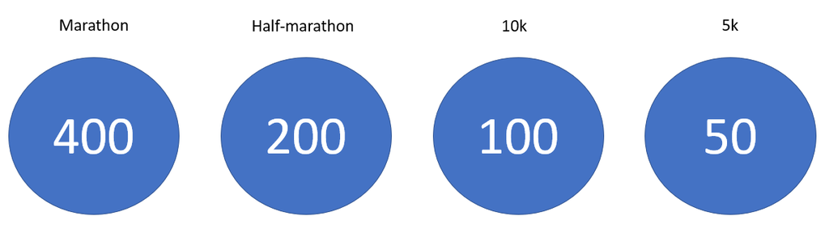

[figure not shown]

## Race details

When does /r/advancedrunning race?

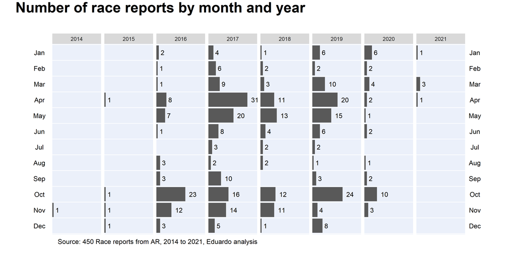

AdvancedRunners race mostly in the Spring (from March to May) and in Autumn (October and November), when conditions are better for racing. Of course, most races are held in these months, so runners are also more likely to chose these months for their races.

## How fast is /r/advancedrunning?

### **Distribution of marathon results**

[figure not shown]

Standing out above all other times, a marathon time between 02:55:00 and 03:00:00 is the most common race time. Running a marathon under 3 hours is a very common goal for advanced runners. 3 hours is a round number, a very challenging time, and in addition, it’s about the time needed to be able to qualify for the Boston Marathon. 15 people have run below 02:35. The distribution has a long right tail, but not may runners go over 4 hours for their marathons.

## How fast does /r/AdvancedRunning want to be?

We saw how fast AdvancedRunners ran, but are their times sufficient to reach their goals?

### **Distribution of goals**

[figure not shown]

## Does /r/AdvancedRunning achieve their goals?

### **Race result vs goal**

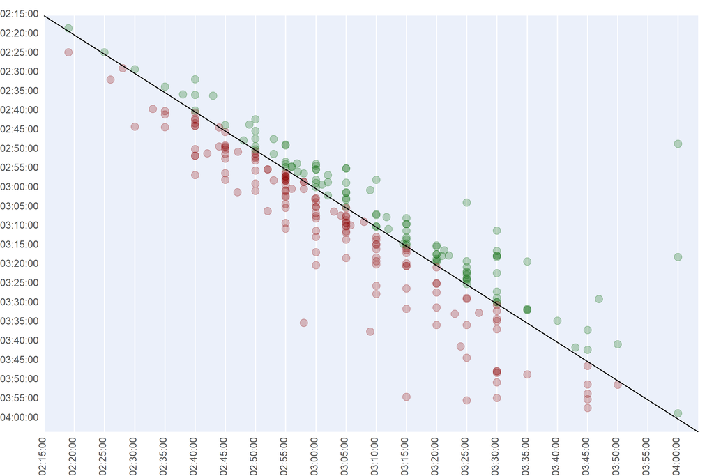

On this chart we plotted the goals of each race on the xx axis, and the actual result from that race on the yy axis.  
We previously saw that most goals are times multiple of 5 minutes (03:00:00, 03:05:00, etc), so that’s why on this chart we almost can see vertical lines of points. The diagonal plotted separates the people who achieved their goals (coloured in green) to the people who did not achieve their goals (coloured in red).  
The higher a runner is from the line, the more they beat their time. Conversely, the lower from the line, the more distance they were from their goal.

## Does /r/AdvancedRunning hit the wall?

### **Median time per mile**

[figure not shown]

### **Median time per mile, by runner type**

[figure not shown]

## Who coaches the fastest runners?

### **Density distribution of times by coach**

[figure not shown]

### **Statistics**

[figure not shown]

## Are /r/AdvancedRunning users improving their times?

### **First marathon time vs Second marathon time**

[figure not shown]

### **Marathon results density distributions over time**

[figure not shown]

## Boston

## The Boston marathon

The Boston Marathon is an annual marathon race hosted by several cities in greater Boston in eastern Massachusetts, United States. It is traditionally held on Patriots’ Day, the third Monday of April. Begun in 1897, the event was inspired by the success of the first marathon competition in the 1896 Summer Olympics. The Boston Marathon is the world’s oldest annual marathon and ranks as one of the world’s best-known road racing events. It is one of six World Marathon Majors. Its course runs from Hopkinton in southern Middlesex County to Copley Square in Boston.

### Boston participants over time

[figure not shown]

### Boston race results

[figure not shown]

### Boston race results, M vs F

[figure not shown]

### Boston race repeaters

[figure not shown]

#### Median time by race number

[figure not shown]

#### Improvements from first marathon to second marathon

[figure not shown]

#### Streakers race time

[figure not shown]

## All marathons

#### Participants

[figure not shown]

#### Women participation

[figure not shown]

#### Age distribution

[figure not shown]

#### Race results

#### All results

[figure not shown]

#### Median over time

[figure not shown]

#### Results by gender

[figure not shown]

#### Median over months

[figure not shown]

#### Results by marathon size

[figure not shown]